# Predict

Mansour haghi

2023-08-16

## Initial configuration

In the first step, the required information has been downloaded and some corrections have been made in the data.

#1-) Packages required

```r
IscaretInstalled <- require("caret")
if(!IscaretInstalled){
  install.packages("caret")
  library("caret")
}
IsrandomForestInstalled <- require("randomForest")
if(!IsrandomForestInstalled){
  install.packages("randomForest")
  library("randomForest")
}
IsRpartInstalled <- require("rpart")
```

```r
if(!IsRpartInstalled){
  install.packages("rpart")
  library("rpart")
}
IsRpartPlotInstalled <- require("rpart.plot")
if(!IsRpartPlotInstalled){
  install.packages("rpart.plot")
  library("rpart.plot")
}

#Set seed for reproducability
set.seed(1000)
```

#2-) Data Processing

#Load the data and Data variables

```r
 trainUrl <- "http://d396qusza40orc.cloudfront.net/predmachlearn/pml-training.csv"
testUrl <- "http://d396qusza40orc.cloudfront.net/predmachlearn/pml-testing.csv"
```

# Download data

```r
training <- read.csv(url(trainUrl))
testing <- read.csv(url(testUrl))
```

#3-)Clean data

```r
#Delete missing values and Remove variables(columns) with zero number
training1 <- read.csv(url(trainUrl), na.strings=c("NA","#DIV/0!",""))
testing1 <- read.csv(url(testUrl), na.strings=c("NA","#DIV/0!",""))
training2<-training1[,colSums(is.na(training1)) == 0]
testing2 <-testing1[,colSums(is.na(testing1)) == 0]

#Delete seven first columns that are not predictors
training3   <-training2[,-c(1:7)]
testing3 <-testing2[,-c(1:7)]
```

#4-) Cross-validation In this section split the training data in training (75%) and testing (25%) data) subsets.

```r
SplitTrain <- createDataPartition(y=training3$classe, p=0.75, list=FALSE)
STraining <- training3[SplitTrain, ]
STesting <- training3[-SplitTrain, ]
dim(STraining)
dim(STesting)
```

[output not shown]

# Exploratory analysis

The variable `classe` contains 5 levels. The plot of the outcome variable shows the frequency of each levels in the subTraining data.

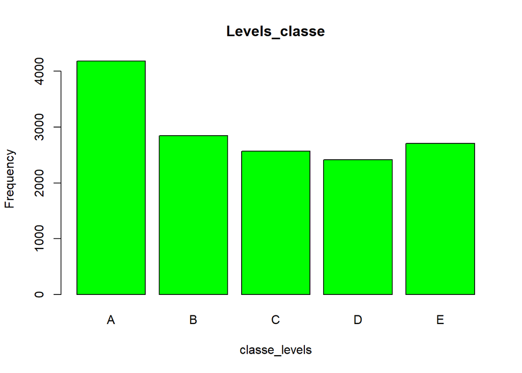

```r
plot(as.factor(STraining$classe), col="green", xlab="classe_levels", ylab="Frequency",main="Levels_classe")
```

#5-) Prediction Models In order to process and predict the data, in this section, a decision tree and random forest are applied to the data.

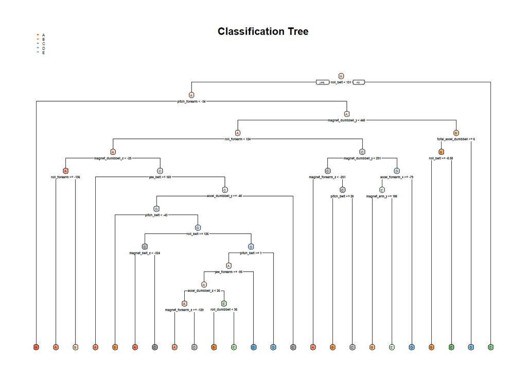

```r
### Decision tree
#Fit model
fit_DT <- rpart(as.factor(classe) ~ ., data=STraining, method="class")
# Perform prediction(model to predict class)
prediction_DT <- predict(fit_DT, STesting, type = "class")
# Plot result
rpart.plot(fit_DT, main="Classification Tree", extra=0, under=TRUE, faclen=0)
```

```r
#Shows the errors of the prediction algorithm with confusionMatrix in testing .

confusionMatrix(prediction_DT, as.factor(STesting$classe))
```

```
## Confusion Matrix and Statistics
##
##           Reference
## Prediction    A    B    C    D    E
##          A 1232  142    8   39   17
##          B   44  598   74   59   72
##          C   48   93  694  122  111
##          D   44   73   63  525   51
##          E   27   43   16   59  650
##
## Overall Statistics
##
##                Accuracy : 0.7543
##                  95% CI : (0.742, 0.7663)
##     No Information Rate : 0.2845
##     P-Value [Acc > NIR] : < 2.2e-16
##
##                   Kappa : 0.689
##
##  Mcnemar's Test P-Value : < 2.2e-16
##
## Statistics by Class:
##
##                      Class: A Class: B Class: C Class: D Class: E
## Sensitivity            0.8832   0.6301   0.8117   0.6530   0.7214
## Specificity            0.9413   0.9370   0.9076   0.9437   0.9638
## Pos Pred Value         0.8567   0.7060   0.6498   0.6944   0.8176
## Neg Pred Value         0.9530   0.9135   0.9580   0.9327   0.9389
## Prevalence             0.2845   0.1935   0.1743   0.1639   0.1837
## Detection Rate         0.2512   0.1219   0.1415   0.1071   0.1325
## Detection Prevalence   0.2932   0.1727   0.2178   0.1542   0.1621
## Balanced Accuracy      0.9122   0.7836   0.8597   0.7983   0.8426
```

```r
### Random forest
#Fit model
fit_RF <- randomForest(as.factor(classe) ~ ., data=STraining, method="class")

# Perform prediction(model to predict class)
prediction_RF <- predict(fit_RF, STesting, type = "class")
```

```r
#Shows the errors of the prediction algorithm with Random Forest in testing .
confusionMatrix(as.factor(STesting$classe), prediction_RF)
```

```
## Confusion Matrix and Statistics
##
##           Reference
## Prediction    A    B    C    D    E
##          A 1395    0    0    0    0
##          B    5  939    5    0    0
##          C    0    7  846    2    0
##          D    0    0   10  793    1
##          E    0    0    0    6  895
##
## Overall Statistics
##
##                Accuracy : 0.9927
##                  95% CI : (0.9899, 0.9949)
##     No Information Rate : 0.2855
##     P-Value [Acc > NIR] : < 2.2e-16
##
##                   Kappa : 0.9907
##
##  Mcnemar's Test P-Value : NA
##
## Statistics by Class:
##
##                      Class: A Class: B Class: C Class: D Class: E
## Sensitivity            0.9964   0.9926   0.9826   0.9900   0.9989
## Specificity            1.0000   0.9975   0.9978   0.9973   0.9985
## Pos Pred Value         1.0000   0.9895   0.9895   0.9863   0.9933
## Neg Pred Value         0.9986   0.9982   0.9963   0.9980   0.9998
## Prevalence             0.2855   0.1929   0.1756   0.1633   0.1827
## Detection Rate         0.2845   0.1915   0.1725   0.1617   0.1825
## Detection Prevalence   0.2845   0.1935   0.1743   0.1639   0.1837
## Balanced Accuracy      0.9982   0.9950   0.9902   0.9937   0.9987
```

#6-) Conclusion

## Result

The confusion matrices show, that the Random Forest algorithm performens better than decision trees. The accuracy for the Random Forest model was 0.9927 (95% CI: (0.9899, 0.9949)) compared to 0.7543 (95% CI: (0.742, 0.7663)) for Decision Tree model. The random Forest model is choosen.

#submission Finally, in order to complete the project, in this section, the submitted files of the project are generated using the random forest algorithm on the test data.

```r
# Perform prediction
predictSubmission <- predict(fit_RF, testing3, type="class")
predictSubmission
```

```
##  1  2  3  4  5  6  7  8  9 10 11 12 13 14 15 16 17 18 19 20
##  B  A  B  A  A  E  D  B  A  A  B  C  B  A  E  E  A  B  B  B
## Levels: A B C D E
```